# Week 1 HW : Polynomial Regression

## 패키지 불러오기

```python
import numpy as np
np.set_printoptions(precision=3) # numpy  float 출력 옵션 변경 - 소수점 셋째자리까지 출력
import pandas as pd
pd.set_option('display.precision', 3)
%matplotlib inline
import matplotlib.pyplot as plt
import seaborn as sns
import math
```

## 데이터 불러오기

```python
bike = pd.read_csv('./data/bike-sharing-dataset/hour.csv')
print(bike.shape)
bike
```

```
(17379, 17)
```

|  | instant | dteday | season | yr | mnth | hr | holiday | weekday | workingday | weathersit | temp | atemp | hum | windspeed | casual | registered | cnt |
| --- | --- | --- | --- | --- | --- | --- | --- | --- | --- | --- | --- | --- | --- | --- | --- | --- | --- |
| 0 | 1 | 2011-01-01 | 1 | 0 | 1 | 0 | 0 | 6 | 0 | 1 | 0.24 | 0.288 | 0.81 | 0.000 | 3 | 13 | 16 |
| 1 | 2 | 2011-01-01 | 1 | 0 | 1 | 1 | 0 | 6 | 0 | 1 | 0.22 | 0.273 | 0.80 | 0.000 | 8 | 32 | 40 |
| 2 | 3 | 2011-01-01 | 1 | 0 | 1 | 2 | 0 | 6 | 0 | 1 | 0.22 | 0.273 | 0.80 | 0.000 | 5 | 27 | 32 |
| 3 | 4 | 2011-01-01 | 1 | 0 | 1 | 3 | 0 | 6 | 0 | 1 | 0.24 | 0.288 | 0.75 | 0.000 | 3 | 10 | 13 |
| 4 | 5 | 2011-01-01 | 1 | 0 | 1 | 4 | 0 | 6 | 0 | 1 | 0.24 | 0.288 | 0.75 | 0.000 | 0 | 1 | 1 |
| 5 | 6 | 2011-01-01 | 1 | 0 | 1 | 5 | 0 | 6 | 0 | 2 | 0.24 | 0.258 | 0.75 | 0.090 | 0 | 1 | 1 |
| 6 | 7 | 2011-01-01 | 1 | 0 | 1 | 6 | 0 | 6 | 0 | 1 | 0.22 | 0.273 | 0.80 | 0.000 | 2 | 0 | 2 |
| 7 | 8 | 2011-01-01 | 1 | 0 | 1 | 7 | 0 | 6 | 0 | 1 | 0.20 | 0.258 | 0.86 | 0.000 | 1 | 2 | 3 |
| 8 | 9 | 2011-01-01 | 1 | 0 | 1 | 8 | 0 | 6 | 0 | 1 | 0.24 | 0.288 | 0.75 | 0.000 | 1 | 7 | 8 |
| 9 | 10 | 2011-01-01 | 1 | 0 | 1 | 9 | 0 | 6 | 0 | 1 | 0.32 | 0.348 | 0.76 | 0.000 | 8 | 6 | 14 |
| 10 | 11 | 2011-01-01 | 1 | 0 | 1 | 10 | 0 | 6 | 0 | 1 | 0.38 | 0.394 | 0.76 | 0.254 | 12 | 24 | 36 |
| 11 | 12 | 2011-01-01 | 1 | 0 | 1 | 11 | 0 | 6 | 0 | 1 | 0.36 | 0.333 | 0.81 | 0.284 | 26 | 30 | 56 |
| 12 | 13 | 2011-01-01 | 1 | 0 | 1 | 12 | 0 | 6 | 0 | 1 | 0.42 | 0.424 | 0.77 | 0.284 | 29 | 55 | 84 |
| 13 | 14 | 2011-01-01 | 1 | 0 | 1 | 13 | 0 | 6 | 0 | 2 | 0.46 | 0.455 | 0.72 | 0.298 | 47 | 47 | 94 |
| 14 | 15 | 2011-01-01 | 1 | 0 | 1 | 14 | 0 | 6 | 0 | 2 | 0.46 | 0.455 | 0.72 | 0.284 | 35 | 71 | 106 |
| 15 | 16 | 2011-01-01 | 1 | 0 | 1 | 15 | 0 | 6 | 0 | 2 | 0.44 | 0.439 | 0.77 | 0.298 | 40 | 70 | 110 |
| 16 | 17 | 2011-01-01 | 1 | 0 | 1 | 16 | 0 | 6 | 0 | 2 | 0.42 | 0.424 | 0.82 | 0.298 | 41 | 52 | 93 |
| 17 | 18 | 2011-01-01 | 1 | 0 | 1 | 17 | 0 | 6 | 0 | 2 | 0.44 | 0.439 | 0.82 | 0.284 | 15 | 52 | 67 |
| 18 | 19 | 2011-01-01 | 1 | 0 | 1 | 18 | 0 | 6 | 0 | 3 | 0.42 | 0.424 | 0.88 | 0.254 | 9 | 26 | 35 |
| 19 | 20 | 2011-01-01 | 1 | 0 | 1 | 19 | 0 | 6 | 0 | 3 | 0.42 | 0.424 | 0.88 | 0.254 | 6 | 31 | 37 |
| 20 | 21 | 2011-01-01 | 1 | 0 | 1 | 20 | 0 | 6 | 0 | 2 | 0.40 | 0.409 | 0.87 | 0.254 | 11 | 25 | 36 |
| 21 | 22 | 2011-01-01 | 1 | 0 | 1 | 21 | 0 | 6 | 0 | 2 | 0.40 | 0.409 | 0.87 | 0.194 | 3 | 31 | 34 |
| 22 | 23 | 2011-01-01 | 1 | 0 | 1 | 22 | 0 | 6 | 0 | 2 | 0.40 | 0.409 | 0.94 | 0.224 | 11 | 17 | 28 |
| 23 | 24 | 2011-01-01 | 1 | 0 | 1 | 23 | 0 | 6 | 0 | 2 | 0.46 | 0.455 | 0.88 | 0.298 | 15 | 24 | 39 |
| 24 | 25 | 2011-01-02 | 1 | 0 | 1 | 0 | 0 | 0 | 0 | 2 | 0.46 | 0.455 | 0.88 | 0.298 | 4 | 13 | 17 |
| 25 | 26 | 2011-01-02 | 1 | 0 | 1 | 1 | 0 | 0 | 0 | 2 | 0.44 | 0.439 | 0.94 | 0.254 | 1 | 16 | 17 |
| 26 | 27 | 2011-01-02 | 1 | 0 | 1 | 2 | 0 | 0 | 0 | 2 | 0.42 | 0.424 | 1.00 | 0.284 | 1 | 8 | 9 |
| 27 | 28 | 2011-01-02 | 1 | 0 | 1 | 3 | 0 | 0 | 0 | 2 | 0.46 | 0.455 | 0.94 | 0.194 | 2 | 4 | 6 |
| 28 | 29 | 2011-01-02 | 1 | 0 | 1 | 4 | 0 | 0 | 0 | 2 | 0.46 | 0.455 | 0.94 | 0.194 | 2 | 1 | 3 |
| 29 | 30 | 2011-01-02 | 1 | 0 | 1 | 6 | 0 | 0 | 0 | 3 | 0.42 | 0.424 | 0.77 | 0.298 | 0 | 2 | 2 |
| ... | ... | ... | ... | ... | ... | ... | ... | ... | ... | ... | ... | ... | ... | ... | ... | ... | ... |
| 17349 | 17350 | 2012-12-30 | 1 | 1 | 12 | 18 | 0 | 0 | 0 | 2 | 0.24 | 0.212 | 0.44 | 0.298 | 12 | 113 | 125 |
| 17350 | 17351 | 2012-12-30 | 1 | 1 | 12 | 19 | 0 | 0 | 0 | 1 | 0.34 | 0.364 | 0.61 | 0.000 | 16 | 86 | 102 |
| 17351 | 17352 | 2012-12-30 | 1 | 1 | 12 | 20 | 0 | 0 | 0 | 1 | 0.22 | 0.197 | 0.47 | 0.328 | 9 | 63 | 72 |
| 17352 | 17353 | 2012-12-30 | 1 | 1 | 12 | 21 | 0 | 0 | 0 | 1 | 0.20 | 0.212 | 0.51 | 0.164 | 5 | 42 | 47 |
| 17353 | 17354 | 2012-12-30 | 1 | 1 | 12 | 22 | 0 | 0 | 0 | 1 | 0.20 | 0.197 | 0.55 | 0.194 | 6 | 30 | 36 |
| 17354 | 17355 | 2012-12-30 | 1 | 1 | 12 | 23 | 0 | 0 | 0 | 1 | 0.20 | 0.197 | 0.51 | 0.224 | 10 | 39 | 49 |
| 17355 | 17356 | 2012-12-31 | 1 | 1 | 12 | 0 | 0 | 1 | 1 | 1 | 0.18 | 0.182 | 0.55 | 0.194 | 4 | 30 | 34 |
| 17356 | 17357 | 2012-12-31 | 1 | 1 | 12 | 1 | 0 | 1 | 1 | 1 | 0.18 | 0.182 | 0.55 | 0.194 | 6 | 13 | 19 |
| 17357 | 17358 | 2012-12-31 | 1 | 1 | 12 | 2 | 0 | 1 | 1 | 1 | 0.16 | 0.167 | 0.59 | 0.164 | 3 | 8 | 11 |
| 17358 | 17359 | 2012-12-31 | 1 | 1 | 12 | 3 | 0 | 1 | 1 | 1 | 0.16 | 0.182 | 0.59 | 0.104 | 0 | 1 | 1 |
| 17359 | 17360 | 2012-12-31 | 1 | 1 | 12 | 4 | 0 | 1 | 1 | 1 | 0.14 | 0.167 | 0.69 | 0.104 | 0 | 3 | 3 |
| 17360 | 17361 | 2012-12-31 | 1 | 1 | 12 | 5 | 0 | 1 | 1 | 1 | 0.16 | 0.151 | 0.64 | 0.194 | 0 | 9 | 9 |
| 17361 | 17362 | 2012-12-31 | 1 | 1 | 12 | 6 | 0 | 1 | 1 | 1 | 0.16 | 0.167 | 0.64 | 0.164 | 0 | 40 | 40 |
| 17362 | 17363 | 2012-12-31 | 1 | 1 | 12 | 7 | 0 | 1 | 1 | 1 | 0.16 | 0.182 | 0.64 | 0.134 | 2 | 83 | 85 |
| 17363 | 17364 | 2012-12-31 | 1 | 1 | 12 | 8 | 0 | 1 | 1 | 1 | 0.14 | 0.151 | 0.69 | 0.134 | 9 | 187 | 196 |
| 17364 | 17365 | 2012-12-31 | 1 | 1 | 12 | 9 | 0 | 1 | 1 | 2 | 0.18 | 0.212 | 0.64 | 0.104 | 13 | 144 | 157 |
| 17365 | 17366 | 2012-12-31 | 1 | 1 | 12 | 10 | 0 | 1 | 1 | 2 | 0.20 | 0.212 | 0.69 | 0.134 | 33 | 87 | 120 |
| 17366 | 17367 | 2012-12-31 | 1 | 1 | 12 | 11 | 0 | 1 | 1 | 2 | 0.22 | 0.227 | 0.60 | 0.194 | 43 | 114 | 157 |
| 17367 | 17368 | 2012-12-31 | 1 | 1 | 12 | 12 | 0 | 1 | 1 | 2 | 0.24 | 0.227 | 0.56 | 0.194 | 52 | 172 | 224 |
| 17368 | 17369 | 2012-12-31 | 1 | 1 | 12 | 13 | 0 | 1 | 1 | 2 | 0.26 | 0.258 | 0.44 | 0.164 | 38 | 165 | 203 |
| 17369 | 17370 | 2012-12-31 | 1 | 1 | 12 | 14 | 0 | 1 | 1 | 2 | 0.28 | 0.273 | 0.45 | 0.224 | 62 | 185 | 247 |
| 17370 | 17371 | 2012-12-31 | 1 | 1 | 12 | 15 | 0 | 1 | 1 | 2 | 0.28 | 0.288 | 0.45 | 0.134 | 69 | 246 | 315 |
| 17371 | 17372 | 2012-12-31 | 1 | 1 | 12 | 16 | 0 | 1 | 1 | 2 | 0.26 | 0.258 | 0.48 | 0.194 | 30 | 184 | 214 |
| 17372 | 17373 | 2012-12-31 | 1 | 1 | 12 | 17 | 0 | 1 | 1 | 2 | 0.26 | 0.288 | 0.48 | 0.090 | 14 | 150 | 164 |
| 17373 | 17374 | 2012-12-31 | 1 | 1 | 12 | 18 | 0 | 1 | 1 | 2 | 0.26 | 0.273 | 0.48 | 0.134 | 10 | 112 | 122 |
| 17374 | 17375 | 2012-12-31 | 1 | 1 | 12 | 19 | 0 | 1 | 1 | 2 | 0.26 | 0.258 | 0.60 | 0.164 | 11 | 108 | 119 |
| 17375 | 17376 | 2012-12-31 | 1 | 1 | 12 | 20 | 0 | 1 | 1 | 2 | 0.26 | 0.258 | 0.60 | 0.164 | 8 | 81 | 89 |
| 17376 | 17377 | 2012-12-31 | 1 | 1 | 12 | 21 | 0 | 1 | 1 | 1 | 0.26 | 0.258 | 0.60 | 0.164 | 7 | 83 | 90 |
| 17377 | 17378 | 2012-12-31 | 1 | 1 | 12 | 22 | 0 | 1 | 1 | 1 | 0.26 | 0.273 | 0.56 | 0.134 | 13 | 48 | 61 |
| 17378 | 17379 | 2012-12-31 | 1 | 1 | 12 | 23 | 0 | 1 | 1 | 1 | 0.26 | 0.273 | 0.65 | 0.134 | 12 | 37 | 49 |

17379 rows × 17 columns

[output not shown]

- instant : ID 변수  
  삭제
- dteday, season, yr, mnth, hr : 날짜 관련 변수  
  dteday에서 연, 월, 일 슬라이싱 하고 yr, mnth는 삭제할래
- holiday, weekday, workingday : 요일 관련 변수  
  weekday가 workingday와 holiday로 나뉘지 않을까 함, 그러면 weekday만 남기는 게 좋을 수도
- weathersit, temp, atemp, hum, windspeed : 날씨 관련 변수  
  temp와 atemp는 비슷할 것 같음, 그러면 temp만 남기자
- casual, registered, cnt  
  아마도 casual과 registered 합치면 cnt 되는 것 같음, 그러면 cnt만 남기자

```python
bike.info() # NA 확인
```

```
<class 'pandas.core.frame.DataFrame'>
RangeIndex: 17379 entries, 0 to 17378
Data columns (total 17 columns):
instant       17379 non-null int64
dteday        17379 non-null object
season        17379 non-null int64
yr            17379 non-null int64
mnth          17379 non-null int64
hr            17379 non-null int64
holiday       17379 non-null int64
weekday       17379 non-null int64
workingday    17379 non-null int64
weathersit    17379 non-null int64
temp          17379 non-null float64
atemp         17379 non-null float64
hum           17379 non-null float64
windspeed     17379 non-null float64
casual        17379 non-null int64
registered    17379 non-null int64
cnt           17379 non-null int64
dtypes: float64(4), int64(12), object(1)
memory usage: 2.3+ MB
```

## Preprocessing

```python
bike = bike.drop('instant', axis=1)
```

### 날짜 관련 변수

```python
bike['date'] = pd.to_datetime(bike['dteday'])
bike['date-year'] = bike['date'].dt.year # 연만 추출
bike['date-month'] = bike['date'].dt.month #월만 추출
bike['date-day'] = bike['date'].dt.day # 일만 추출
```

```python
bike[['dteday', 'date', 'date-year', 'date-month', 'date-day']].head() # 전처리 결과 확인
```

|  | dteday | date | date-year | date-month | date-day |
| --- | --- | --- | --- | --- | --- |
| 0 | 2011-01-01 | 2011-01-01 | 2011 | 1 | 1 |
| 1 | 2011-01-01 | 2011-01-01 | 2011 | 1 | 1 |
| 2 | 2011-01-01 | 2011-01-01 | 2011 | 1 | 1 |
| 3 | 2011-01-01 | 2011-01-01 | 2011 | 1 | 1 |
| 4 | 2011-01-01 | 2011-01-01 | 2011 | 1 | 1 |

```python
bike[['dteday', 'date', 'date-year', 'date-month', 'date-day']].tail() # 전처리 결과 확인
```

|  | dteday | date | date-year | date-month | date-day |
| --- | --- | --- | --- | --- | --- |
| 17374 | 2012-12-31 | 2012-12-31 | 2012 | 12 | 31 |
| 17375 | 2012-12-31 | 2012-12-31 | 2012 | 12 | 31 |
| 17376 | 2012-12-31 | 2012-12-31 | 2012 | 12 | 31 |
| 17377 | 2012-12-31 | 2012-12-31 | 2012 | 12 | 31 |
| 17378 | 2012-12-31 | 2012-12-31 | 2012 | 12 | 31 |

```python
# 필요없는 변수 삭제
bike = bike.drop(['dteday', 'yr', 'mnth', 'date'], axis=1)
```

### 요일 관련 변수

```python
# 요일 숫자로 되어있는 거 헷갈려서 일월화수목금토로 바꿈
bike.loc[bike['weekday']==0, 'dayofweek'] = 'Sunday'
bike.loc[bike['weekday']==1, 'dayofweek'] = 'Monday'
bike.loc[bike['weekday']==2, 'dayofweek'] = 'Tuesday'
bike.loc[bike['weekday']==3, 'dayofweek'] = 'Wednesday'
bike.loc[bike['weekday']==4, 'dayofweek'] = 'Thursday'
bike.loc[bike['weekday']==5, 'dayofweek'] = 'Friday'
bike.loc[bike['weekday']==6, 'dayofweek'] = 'Saturday'
```

```python
bike[['weekday', 'dayofweek']].head()
```

|  | weekday | dayofweek |
| --- | --- | --- |
| 0 | 6 | Saturday |
| 1 | 6 | Saturday |
| 2 | 6 | Saturday |
| 3 | 6 | Saturday |
| 4 | 6 | Saturday |

```python
bike[['weekday', 'dayofweek']].tail()
```

|  | weekday | dayofweek |
| --- | --- | --- |
| 17374 | 1 | Monday |
| 17375 | 1 | Monday |
| 17376 | 1 | Monday |
| 17377 | 1 | Monday |
| 17378 | 1 | Monday |

```python
# 필요없는 변수 삭제
bike = bike.drop('weekday', axis=1)
```

```python
# 변수명 변경
bike.columns
bike.columns = ['season', 'hour', 'holiday', 'workingday', 'weathersit', 'temp', 'atemp', 'hum', 'windspeed', 'casual', 'registered', 'cnt', 'year', 'month', 'day', 'dayofweek']
```

## EDA

### 날짜 관련 변수

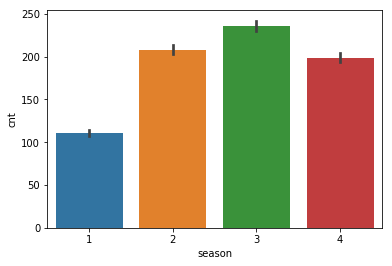

```python
# season 시각화
sns.barplot(data=bike, x='season', y='cnt')
```

봄보다 겨울에 자전거 대여량 많은 게 약간 이상함..

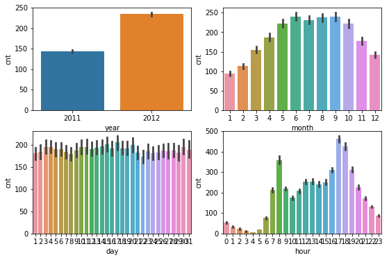

```python
# year, month, day, hour 시각화
figure, ((ax1, ax2), (ax3, ax4)) = plt.subplots(nrows=2, ncols=2, figsize=(9,6))
sns.barplot(data=bike, x="year", y="cnt", ax=ax1)
sns.barplot(data=bike, x="month", y="cnt", ax=ax2)
sns.barplot(data=bike, x="day", y="cnt", ax=ax3)
sns.barplot(data=bike, x="hour", y="cnt", ax=ax4)
```

- 2011년보다 2012년에 자전거 대여량 높음
- 겨울보다 여름에 자전거 대여량 높음, 그런데 1,2월에 비해 12월이 좀 특징적으로 높은 것 같음
- 일에 있어 일정 주기가 있어보임, 하지만 딱히 특징적이지 않음, 안 쓰는 게 나을 수도
- 새벽엔 자전거 대여량 없음, 오후에 많음, 아침시간과 저녁시간 즉 출퇴근시간에 특징적으로 높음 -> hour + workingday 조합해서 보자

```python
# 시계열로 보기 위해서 연 + 월 합침
bike['year_str'] = bike['year'].astype('str')
bike['month_str'] = bike['month'].astype('str')
bike['year_month_str'] = bike['year_str'] + '-' + bike['month_str']

bike[['year', 'month', 'year_month_str']].head()
```

|  | year | month | year_month_str |
| --- | --- | --- | --- |
| 0 | 2011 | 1 | 2011-1 |
| 1 | 2011 | 1 | 2011-1 |
| 2 | 2011 | 1 | 2011-1 |
| 3 | 2011 | 1 | 2011-1 |
| 4 | 2011 | 1 | 2011-1 |

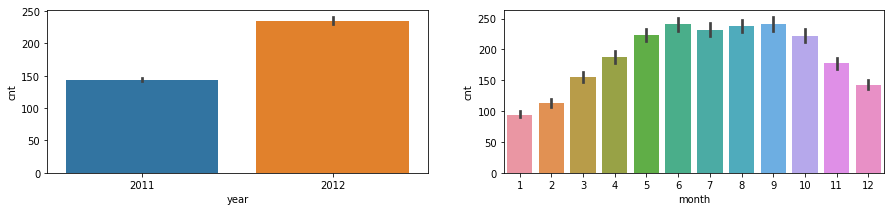

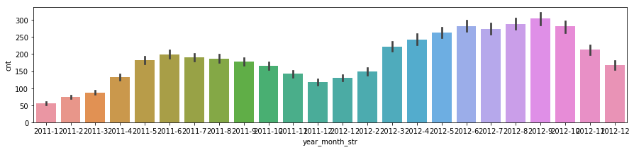

```python
# year + month 시각화
figure, (ax1, ax2) = plt.subplots(nrows=1, ncols=2, figsize=(15,3))
sns.barplot(data=bike, x='year', y='cnt', ax=ax1)
sns.barplot(data=bike, x='month', y='cnt', ax=ax2)

figure, ax3 = plt.subplots(nrows=1, ncols=1, figsize=(15,3))
sns.barplot(data=bike, x="year_month_str", y="cnt", ax=ax3)
```

### 요일 관련 변수

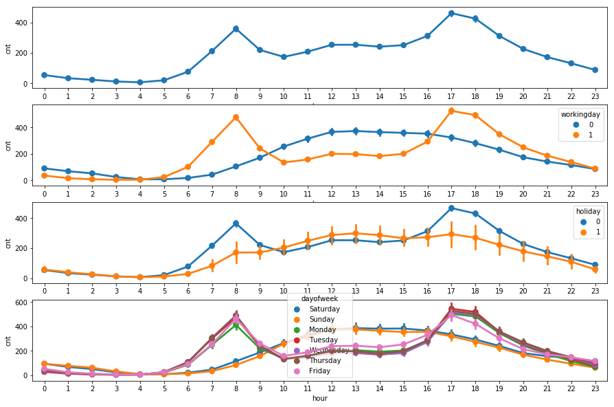

```python
figure, (ax1, ax2, ax3, ax4) = plt.subplots(nrows=4, ncols=1, figsize=(15, 10))

sns.pointplot(data=bike, x='hour', y='cnt', ax=ax1)
sns.pointplot(data=bike, x='hour', y='cnt', hue='workingday', ax=ax2)
sns.pointplot(data=bike, x='hour', y='cnt', hue='holiday', ax=ax3)
sns.pointplot(data=bike, x='hour', y='cnt', hue='dayofweek', ax=ax4)
```

월화수목금 (workingday) : 아침 저녁 시간대에 높음 / 토일 (holiday) : 아침 이후 ~ 저녁 이전 시간대에 높음  
=> workingday만 쓸래

### 날씨 관련 변수

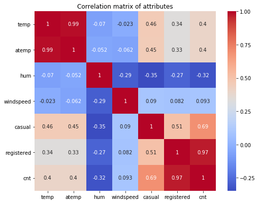

```python
cor_matrix = bike[['temp', 'atemp', 'hum', 'windspeed', 'casual', 'registered', 'cnt']].corr()

fig,ax=plt.subplots(1, figsize=(8,6.5))
sns.heatmap(cor_matrix, annot=True, cmap='coolwarm', ax=ax)
ax.set_title('Correlation matrix of attributes')
plt.show()
```

temp랑 atemp 높음 => temp만 사용  
casual, registered, cnt 높음 => cnt만 사용

## Polynomial Regression

### TrainSet TestSet Split

```python
var_names = ['year', 'month', 'hour', 'workingday', 'weathersit', 'temp', 'hum', 'windspeed', 'cnt']
df = bike[var_names]
```

```python
df.info()
```

```
<class 'pandas.core.frame.DataFrame'>
RangeIndex: 17379 entries, 0 to 17378
Data columns (total 9 columns):
year          17379 non-null int64
month         17379 non-null int64
hour          17379 non-null int64
workingday    17379 non-null int64
weathersit    17379 non-null int64
temp          17379 non-null float64
hum           17379 non-null float64
windspeed     17379 non-null float64
cnt           17379 non-null int64
dtypes: float64(3), int64(6)
memory usage: 1.2 MB
```

```python
from sklearn.model_selection import train_test_split
Y = df['cnt']
X = df[['year', 'month', 'hour', 'workingday', 'weathersit', 'temp', 'hum', 'windspeed']]
X_train, X_test, Y_train, Y_test = train_test_split(X, Y, test_size=30, train_size=70, random_state=99, shuffle=True)
```

### Fitting

```python
from sklearn.linear_model import LinearRegression
from sklearn.preprocessing import PolynomialFeatures
```

```python
poly = PolynomialFeatures(degree=2)
```

```python
print(poly)
```

```
PolynomialFeatures(degree=2, include_bias=True, interaction_only=False)
```

```python
X_train_poly = poly.fit_transform(X_train)
X_test_poly = poly.fit_transform(X_test)
```

```python
linreg= LinearRegression(fit_intercept=False)
linreg.fit(X_train_poly, Y_train)
```

```
LinearRegression(copy_X=True, fit_intercept=False, n_jobs=None,
         normalize=False)
```

```python
train_prediction=linreg.predict(X_train_poly)
test_prediction=linreg.predict(X_test_poly)
print(train_prediction)
print(test_prediction)
```

```
[ 1.942e+02  1.562e+02  1.985e+02  3.529e+02  1.292e+02  1.422e+02
  2.203e+02  1.290e+02  2.777e+00  6.173e+01  4.838e+01  2.231e+02
  2.318e+02 -6.433e-01  5.730e+02  5.791e+00  2.195e+00 -7.293e+01
  6.101e+01  4.531e+00  1.402e+02  3.061e+02 -7.536e+01  3.790e+02
  3.287e+02  2.723e+02  4.739e+02  1.583e+02  4.960e+00  2.199e+02
  3.558e+02  1.809e+02 -9.720e+00  1.504e+02  1.391e+02  1.597e+02
  6.772e+02  1.643e+02  6.846e+01  1.624e+02  2.664e+02  3.964e+02
  1.436e+02  1.531e+02  2.604e+02  2.930e+02  6.771e+02  1.822e+02
  2.771e+01  1.852e+02 -4.997e+01  5.923e+02  1.439e+02  2.564e+02
  1.915e+02  1.539e+02  1.871e+00  1.917e+02  3.520e+01  5.434e+02
 -6.094e+01  3.827e+02  1.555e+02  1.956e+02 -3.052e+00  2.413e+02
  3.333e+02  1.036e+02  4.831e+01  2.394e+02]
[-110.17   268.057  190.816  197.478  -34.131   52.831   -7.919  175.565
  -15.665  312.634   -7.297   46.755  -11.265   99.786   71.207  356.402
 -106.057  590.912 -401.367  -24.575  197.549  175.268  321.273   19.525
  273.391  164.483  -21.333  223.229  286.039  349.245]
```

```
[8.691716795091095, -25.73680592150111, -25.804089585986183, -25.688381378721974, -25.588165344671037, -25.501039521234087, -25.42457194439099, -25.357021214558987, -25.297571688066338, -25.244201260133273, -25.195828273315996]
[10.552432882371985, 13.708471843337302, 12.628213398919018, 12.628330166324648, 12.628459885608454, 12.628590133040843, 12.628720877323016, 12.628852118350567, 12.628983855971429, 12.629116090091047, 12.629248820628087]
```

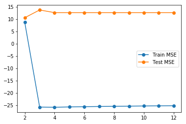

```python
train_mse=[]
test_mse=[]
for i in np.arange(2,13):
    poly = PolynomialFeatures(degree=i)
    X_train_poly = poly.fit_transform(X_train)
    X_test_poly = poly.fit_transform(X_test)

    linreg=LinearRegression(fit_intercept=False)
    linreg.fit(X_train_poly, Y_train)

    train_prediction=linreg.predict(X_train_poly)
    tr_mse = math.log(sum(np.array(train_prediction-Y_train)**2)/len(X_train))
    train_mse.append(tr_mse)

    test_prediction=linreg.predict(X_test_poly)
    te_mse = math.log(sum(np.array(test_prediction-Y_test)**2)/len(X_test))
    test_mse.append(te_mse)
print(train_mse)
print(test_mse)

plt.plot(np.arange(2,13), train_mse, marker='o')
plt.plot(np.arange(2,13), test_mse, marker='o')
plt.legend(['Train MSE', 'Test MSE'])
```